## Overview

“binomial” is a minimal [R](http://www.r-project.org/) package that provides functions to calculate probabilities of a Binomial random variable. There are three types of functions in this package: 1.private: these are auxiliary functions not intended to be called by the user. * `check_prob()` test if an input prob is a valid probability value * `check_trials()` test if an input trials is a valid value for number of trials * `check_success()` test if an input success is a valid value for number of successes * `aux_mean()` returns the mean of the expression * `aux_variable()` returns the variance of the expression * `aux_mode()` returns the mode of the expression * `aux_skewness()` returns the skewness of the expression * `aux_kurtosis()` returns the kurtosis of the expression 2.main: these are the main functions that the user is expected to invoke. * `bin_choose()` calculates the number of combinations in which k successes can occur in n trials * `bin_probability()` calculates the probability of combinations in which k successes can occur in n trials * `bin_distribution()` creates a binomial object (of class `"bindis"`)) * `bin_cumulative()` creates a binomial object (of class `"bincum"`)) * `bin_variable()` creates a binomial object (of class `"binvar"`)) * `bin_mean()` returns a summary measure of “mean” attribute * `bin_variance()` returns a summary measure of “variance” attribute * `bin_mode()` returns a summary measure of “mode” attribute * `bin_skewness()` returns a summary measure of “skewness” attribute * `bin_kurtosis()` returns a summary measure of “kurtosis” attribute 3.methods: these are also public functions that support classes of objects generated by some of the main functions. * `print.binvar()` print the content of an object “binvar” * `summary.binvar()` print a summary description of an object “binvar” * `print.summary.binvar()` a print method for a `"binvar"` object. * `plot.bindis()` graphs a barplot to display the probability histogram of a binomial distribution object “bindis” * `plot.bincum()` graphs the cumulative distribution in ab object “bincum”

## Motivation

This package has been developed to illustrate some of the concepts behind the creation of an R package.

## Usage

```r
library(binomial)
# invoke bin_choose function
bin_choose(n = 5, k = 2)
```

```
#> [1] 10
```

```r
bin_choose(5, 0)
```

```
#> [1] 1
```

```r
bin_choose(5, 1:3)
```

```
#> [1]  5 10 10
```

```r
# probability of getting 2 successes in 5 trials
# (assuming prob of success = 0.5)
bin_probability(success = 2, trials = 5, prob = 0.5)
```

```
#> [1] 0.3125
```

```r
# probabilities of getting 2 or less successes in 5 trials
# (assuming prob of success = 0.5)
bin_probability(success = 0:2, trials = 5, prob = 0.5)
```

```
#> [1] 0.03125 0.15625 0.31250
```

```r
# 55 heads in 100 tosses of a loaded coin with 45% chance of heads
bin_probability(success = 55, trials = 100, prob = 0.45)
```

```
#> [1] 0.01075277
```

```r
# binomial probability distribution
bin_distribution(trials = 5, prob = 0.5)
```

```
#>
#>
#>   success probability
#> 1       0     0.03125
#> 2       1     0.15625
#> 3       2     0.31250
#> 4       3     0.31250
#> 5       4     0.15625
#> 6       5     0.03125
```

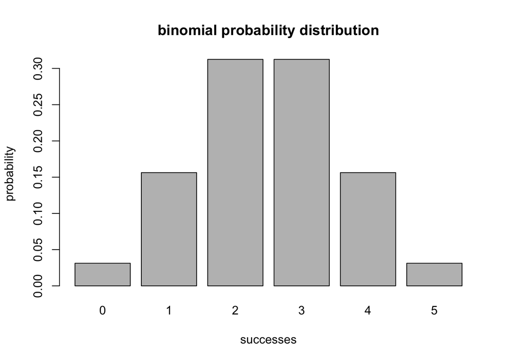

```r
# plotting binomial probability distribution
plot(bin_distribution(trials = 5, prob = 0.5))
```

```r
# binomial cumulative distribution
bin_cumulative(trials = 5, prob = 0.5)
```

```
#>
#>
#>   success probability cumulative
#> 1       0     0.03125    0.03125
#> 2       1     0.15625    0.18750
#> 3       2     0.31250    0.50000
#> 4       3     0.31250    0.81250
#> 5       4     0.15625    0.96875
#> 6       5     0.03125    1.00000
```

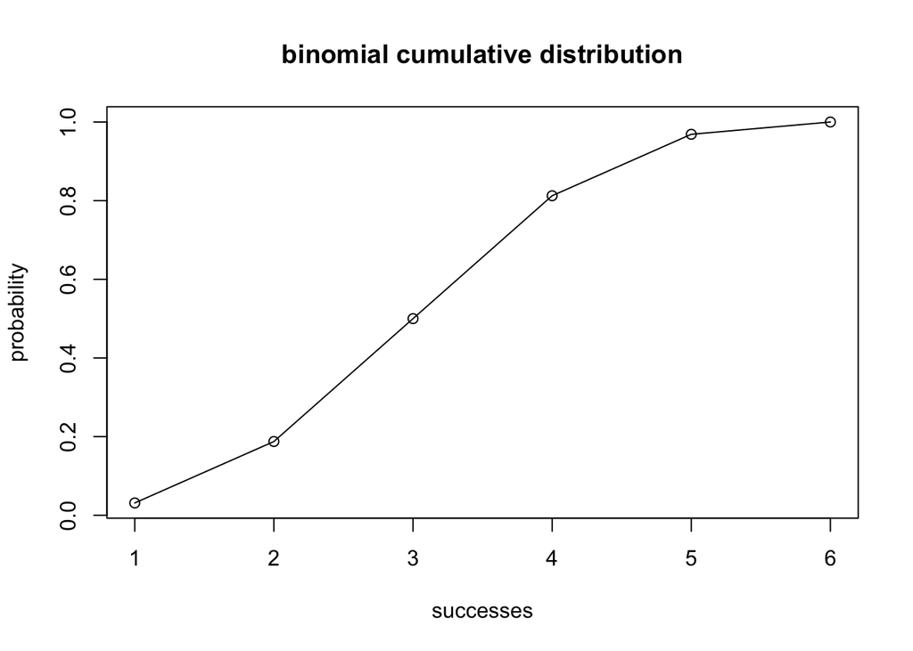

```r
# plotting binomial cumulative distribution
plot(bin_cumulative(trials = 5, prob = 0.5))
```

```r
# invoke bin_variable function
bin1 <- bin_variable(trials = 10, p = 0.3)
bin1
```

```
#> "Binomial variable"
#>
#> Parameters
#> - number of trials: 10
#> - prob of success : 0.3
```

```r
# invoke summary.binvar function
summary(bin_variable(trials = 10, p = 0.3))
```

```
#>
#> Summary Binomial
#>
#> Paramaters
#> - number of trials: 10
#> - prob of success: 0.3
#>
#> Measures
#> - mean: 3
#> - variance: 2.1
#> - mode: 3
#> - skewness: 0.2760262
#> - kurtosis: -0.1238095
```